### Polygon(`geom_polygon()`) is a simple way to draw maps – it draws boundaries for different regions.

#### Step 1: get map data

Use `ggplot2::map_data()` to get the wanted map data.

```r
# install.packages('map') # map package is required
world <- map_data('world')

head(world)
```

```
##        long      lat group order region subregion
## 1 -69.89912 12.45200     1     1  Aruba      <NA>
## 2 -69.89571 12.42300     1     2  Aruba      <NA>
## 3 -69.94219 12.43853     1     3  Aruba      <NA>
## 4 -70.00415 12.50049     1     4  Aruba      <NA>
## 5 -70.06612 12.54697     1     5  Aruba      <NA>
## 6 -70.05088 12.59707     1     6  Aruba      <NA>
```

We can see what map data looks like. Different countries and regions have different `group` number. If you want to get map data other than **world**, try `?map_data`.

#### Step 2: draw the map

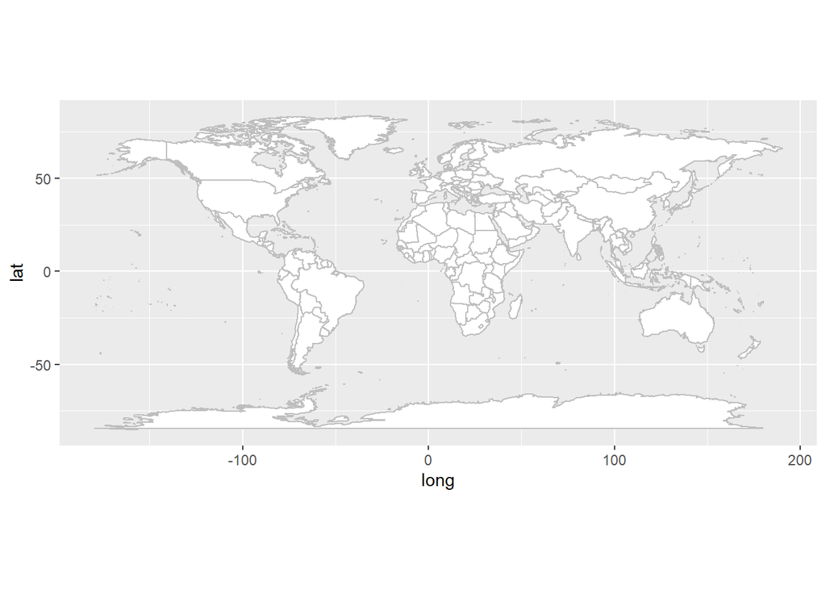

```r
ggplot(world, aes(x = long, y = lat, group = group)) +
  geom_polygon(fill = 'white', # This is the colour within countries' boundaries
               colour = 'grey' # This is background colour
               ) +
  coord_quickmap() # This is map projections, there are many other types of map projections
```

##### What if we use `geom_point()`, instead?

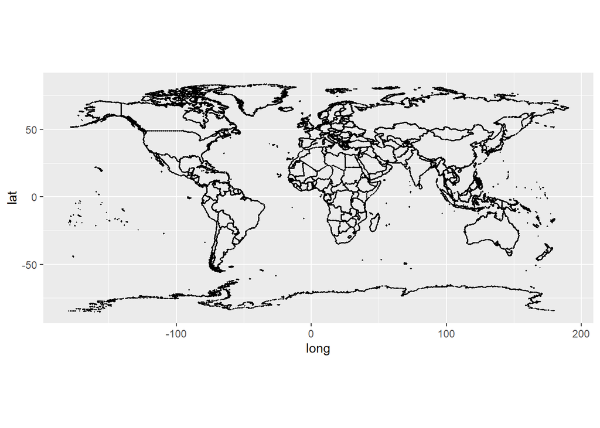

```r
ggplot(world, aes(long, lat, group = group)) +
  geom_point(size = 0.25) +
  coord_quickmap()
```

Now, we can see each country’s boundaries are plotted as points.

### Let’s see what we can do for `who_covid` data

`who_covid` records COVID-19 cases and deaths in the countries of the world. Try to use `?who_covid` to read more information about the data.

```r
head(ggplotIntro::who_covid)
```

```
## # A tibble: 6 x 6
##   name                     who_region cases_cumulativ~ cases_cumulativ~ deaths_cumulati~
##   <chr>                    <chr>                 <dbl>            <dbl>            <dbl>
## 1 Global                   <NA>              232075351            2977.          4752988
## 2 United States of America Americas           42648573           12885.           683243
## 3 India                    South-Eas~         33697581            2442.           447373
## 4 Brazil                   Americas           21351972           10045.           594443
## 5 The United Kingdom       Europe              7701719           11345.           136208
## 6 Russian Federation       Europe              7464708            5115.           205531
## # ... with 1 more variable: deaths_cumulative_total_per_100000_population <dbl>
```

Before we using `geom_polygon()` to draw a map, we need to join `world` data to `who_covid` data, because originally `who_covid` data does not contain countries’ map data.

```r
covid <-
  mutate(ggplotIntro::who_covid, name = case_when(name == "United States of America" ~ "USA",
                          name == "United Kingdom" ~ "UK",
                          TRUE ~ name))
```

Second, merge two data set into one data set.

```r
covid_map <- left_join(covid[-1,], # -1 is to deselect Global data
          world,
          by = c("name" = "region") # select name and region to join by
          )
```

Finally, draw the map.

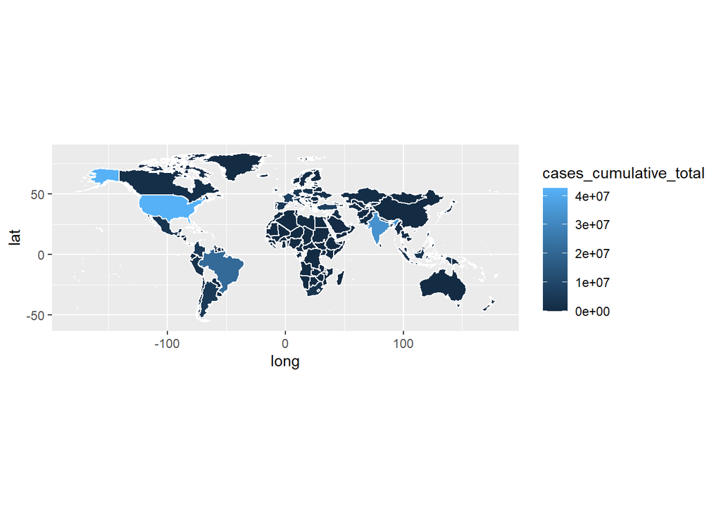

```r
ggplot(data = covid_map, aes(x = long, y = lat, group = group, fill = cases_cumulative_total)) +
  geom_polygon(colour = 'white') +
  coord_quickmap()
```